```python
import py7zr
import os
import numpy as np
import pandas as pd

import matplotlib.pyplot as plt
import seaborn as sns

from scipy import stats
```

# Data Gathering

Import datasets from CSV files by using pandas library

```python
if not os.path.exists("datasets/combined.csv"):
    for item in os.listdir("/home/raychannudam/Documents/capII/datasets"):
        if (item.endswith(".7z")):
            file_name = os.path.abspath("datasets/"+item)
            zip_ref = py7zr.SevenZipFile(file_name)
            zip_ref.extractall("datasets")
            zip_ref.close()
    df_train = pd.read_csv("datasets/train.csv")
    df_test = pd.read_csv("datasets/test.csv")
    df_songs = pd.read_csv("datasets/songs.csv")
    df_song_extra_info = pd.read_csv("datasets/song_extra_info.csv")
    df_members = pd.read_csv("datasets/members.csv")
```

```python
if not os.path.exists("datasets/combined.csv"):
    df_merged = pd.DataFrame()
    df_merged = df_train.merge(df_members, on="msno", how="left")
    df_merged = df_merged.merge(df_songs, on="song_id", how="left")
    df_merged = df_merged.merge(df_song_extra_info, on="song_id", how="left")
    df_merged.to_csv("datasets/combined.csv")
```

Import combined dataset in CSV file by using pandas library

```python
df_train = pd.DataFrame()
df_train = pd.read_csv("datasets/combined.csv", low_memory=False)
df_train.drop("Unnamed: 0", axis=1, inplace=True)
df_train.drop_duplicates(subset=['msno', 'song_id'])
df_train.head()
```

|  | msno | song_id | source_system_tab | source_screen_name | source_type | target | city | bd | gender | registered_via | registration_init_time | expiration_date | song_length | genre_ids | artist_name | composer | lyricist | language | name | isrc |
| --- | --- | --- | --- | --- | --- | --- | --- | --- | --- | --- | --- | --- | --- | --- | --- | --- | --- | --- | --- | --- |
| 0 | FGtllVqz18RPiwJj/edr2gV78zirAiY/9SmYvia+kCg= | BBzumQNXUHKdEBOB7mAJuzok+IJA1c2Ryg/yzTF6tik= | explore | Explore | online-playlist | 1 | 1 | 0 | NaN | 7 | 20120102 | 20171005 | 206471.0 | 359 | Bastille | Dan Smith\| Mark Crew | NaN | 52.0 | Good Grief | GBUM71602854 |
| 1 | Xumu+NIjS6QYVxDS4/t3SawvJ7viT9hPKXmf0RtLNx8= | bhp/MpSNoqoxOIB+/l8WPqu6jldth4DIpCm3ayXnJqM= | my library | Local playlist more | local-playlist | 1 | 13 | 24 | female | 9 | 20110525 | 20170911 | 284584.0 | 1259 | Various Artists | NaN | NaN | 52.0 | Lords of Cardboard | US3C69910183 |
| 2 | Xumu+NIjS6QYVxDS4/t3SawvJ7viT9hPKXmf0RtLNx8= | JNWfrrC7zNN7BdMpsISKa4Mw+xVJYNnxXh3/Epw7QgY= | my library | Local playlist more | local-playlist | 1 | 13 | 24 | female | 9 | 20110525 | 20170911 | 225396.0 | 1259 | Nas | N. Jones、W. Adams、J. Lordan、D. Ingle | NaN | 52.0 | Hip Hop Is Dead(Album Version (Edited)) | USUM70618761 |
| 3 | Xumu+NIjS6QYVxDS4/t3SawvJ7viT9hPKXmf0RtLNx8= | 2A87tzfnJTSWqD7gIZHisolhe4DMdzkbd6LzO1KHjNs= | my library | Local playlist more | local-playlist | 1 | 13 | 24 | female | 9 | 20110525 | 20170911 | 255512.0 | 1019 | Soundway | Kwadwo Donkoh | NaN | -1.0 | Disco Africa | GBUQH1000063 |
| 4 | FGtllVqz18RPiwJj/edr2gV78zirAiY/9SmYvia+kCg= | 3qm6XTZ6MOCU11x8FIVbAGH5l5uMkT3/ZalWG1oo2Gc= | explore | Explore | online-playlist | 1 | 1 | 0 | NaN | 7 | 20120102 | 20171005 | 187802.0 | 1011 | Brett Young | Brett Young\| Kelly Archer\| Justin Ebach | NaN | 52.0 | Sleep Without You | QM3E21606003 |

# Data Exploration (EDA)

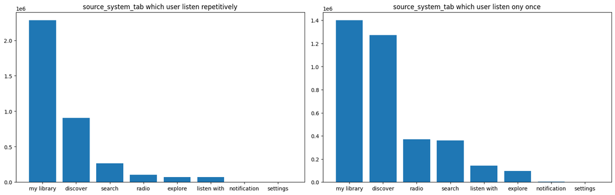

```python
data_1 = df_train[df_train.target == 1].source_system_tab.value_counts().to_dict()
data_0 = df_train[df_train.target == 0].source_system_tab.value_counts().to_dict()
fig, (ax1, ax2) = plt.subplots(1,2, layout="constrained", figsize=(16,5))
ax1.bar(x=list(data_1.keys()), height=list(data_1.values()))
ax1.set_title("source_system_tab which user listen repetitively")
ax2.bar(x=list(data_0.keys()), height=list(data_0.values()))
ax2.set_title("source_system_tab which user listen ony once")
```

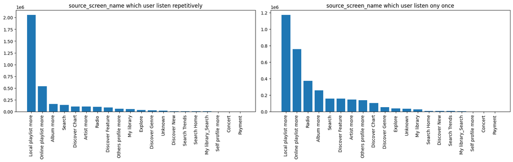

```python
data_1 = df_train[df_train.target == 1].source_screen_name.value_counts().to_dict()
data_0 = df_train[df_train.target == 0].source_screen_name.value_counts().to_dict()
fig, (ax1, ax2) = plt.subplots(1,2, layout="constrained", figsize=(16,5))
ax1.bar(x=list(data_1.keys()), height=list(data_1.values()))
ax1.set_title("source_screen_name which user listen repetitively")
ax1.set_xticklabels(list(data_1.keys()), rotation=90)
ax2.bar(x=list(data_0.keys()), height=list(data_0.values()))
ax2.set_title("source_screen_name which user listen ony once")
ax2.set_xticklabels(list(data_0.keys()), rotation=90)
plt.show()
```

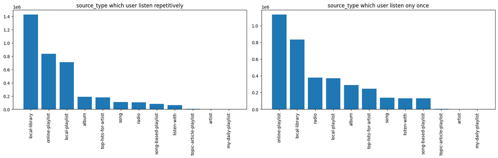

```python
data_1 = df_train[df_train.target == 1].source_type.value_counts().to_dict()
data_0 = df_train[df_train.target == 0].source_type.value_counts().to_dict()
fig, (ax1, ax2) = plt.subplots(1,2, layout="constrained", figsize=(16,5))
ax1.bar(x=list(data_1.keys()), height=list(data_1.values()))
ax1.set_title("source_type which user listen repetitively")
ax1.set_xticklabels(list(data_1.keys()), rotation=90)
ax2.bar(x=list(data_0.keys()), height=list(data_0.values()))
ax2.set_title("source_type which user listen ony once")
ax2.set_xticklabels(list(data_0.keys()), rotation=90)
plt.show()
```

From **upper** data vittualization on feature **source_system_tab**, **source_screen_name** and ***source_type** we can assume that:

- **source_system_tab**
  - user that listen repetitively mostly they browsed from **my library** as top 01, **discover** as top 02 and **search** as top 03
  - user that listen only onece mostly they browsed from **my library** as top 01, **discover** as top 02 and **radio** as top 03
- **source_screen_name**
  - user that listen repetitively mostly they browsed from **Local playlist more** as top 01, **Online playlist more** as top 02 and **Album more** as top 03
  - user that listen only onece mostly they browsed from **Local playlist more** as top 01, **Online playlist more** as top 02 and **Radio** as top 03
- **source_type**
  - user that listen repetitively mostly they browsed from **local-library** as top 01, **online-playlist** as top 02 and **local-playlist** as top 03
  - user that listen only onece mostly they browsed from **online-playlist** as top 01, **local-library** as top 02 and **radio** as top 03

So

- we can keep only **my library**, **discover**, **search** and **radio** for column **source_system_tab**
- we can keep only **Local playlist more**, **Online playlist more**, **Album more**, **Radio** for column **source_screen_name**
- we can keep only **local-library**, **online-playlist**, **local-playlist**, **radio** for column **source_type**

And also

```python
df_temp = df_train.copy()
```

```python
df_train = df_temp

# keep only common 3 category and the rest is replaced by other
df_train.source_system_tab = np.where(
    df_train.source_system_tab.isna(), df_train.source_system_tab,
    np.where(
        (df_train.target == 1) & df_train.source_system_tab.isin(['my library', 'discover', 'search']), df_train.source_system_tab,
        np.where(
            (df_train.target == 0) & df_train.source_system_tab.isin(['my library', 'discover', 'radio']), df_train.source_system_tab, 'other')))

df_train.source_screen_name = np.where(
    df_train.source_screen_name.isna(), df_train.source_screen_name,
    np.where(
        (df_train.target == 1) & df_train.source_screen_name.isin(['Local playlist more', 'Online playlist more', 'Album more']), df_train.source_screen_name,
        np.where(
            (df_train.target == 0) & df_train.source_screen_name.isin(['Local playlist more', 'Online playlist more', 'Radio']), df_train.source_screen_name, 'other')))

df_train.source_type = np.where(
    df_train.source_type.isna(), df_train.source_type,
    np.where(
        (df_train.target == 1) & df_train.source_type.isin(['local-library', 'online-playlist', 'local-playlist']), df_train.source_type,
        np.where(
            (df_train.target == 0)& df_train.source_type.isin(['online-playlist', 'local-library', 'radio']), df_train.source_type, 'other')))
```

```python
print(df_train.genre_ids.iloc[10:15])
```

```
10        465
11        465
12        465
13        458
14    465|458
Name: genre_ids, dtype: object
```

For **genre_ids** column, it contains **|** which represents as a seperator. So it means that this column contain multiple genre_id.  
So the first thing we need to do is to convert it from string to list

```python
df_train['genre_ids'] = df_train['genre_ids'].astype('string')
df_train.genre_ids = df_train[df_train.genre_ids.notna()].genre_ids.apply(lambda x: x.split("|"))
print(df_train.genre_ids.iloc[10:15])
```

```
10         [465]
11         [465]
12         [465]
13         [458]
14    [465, 458]
Name: genre_ids, dtype: object
```

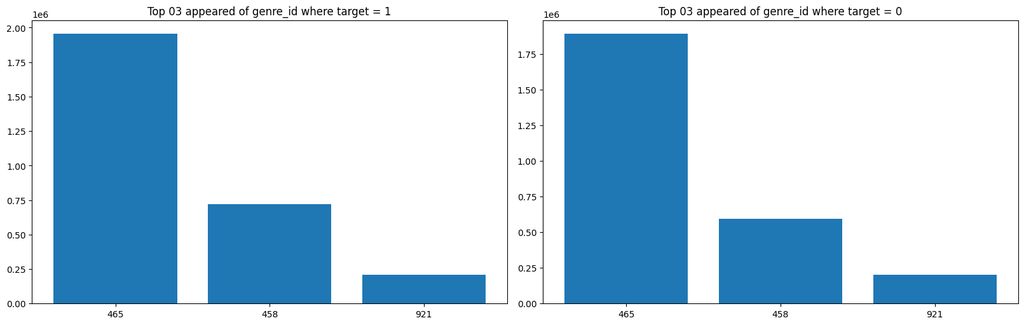

```python
flattened_genre_ids_01 = [genre_id for genre_ids in df_train[df_train.target == 1]['genre_ids'] if type(genre_ids) != float for genre_id in genre_ids]
flattened_genre_ids_00 = [genre_id for genre_ids in df_train[df_train.target == 0]['genre_ids'] if type(genre_ids) != float for genre_id in genre_ids]
value_counts_01 = pd.Series(flattened_genre_ids_01).value_counts()[:3].to_dict()
value_counts_00 = pd.Series(flattened_genre_ids_00).value_counts()[:3].to_dict()
fig, (ax1, ax2) = plt.subplots(1,2, layout="constrained", figsize=(16,5))
ax1.bar(list(value_counts_01.keys()), list(value_counts_01.values()))
ax1.set_title("Top 03 appeared of genre_id where target = 1")
ax2.bar(list(value_counts_00.keys()), list(value_counts_00.values()))
ax2.set_title("Top 03 appeared of genre_id where target = 0")

plt.show()
```

```python
print(f"Max number of genre id in a song: {np.max([len(genre_ids) for genre_ids in df_train['genre_ids'] if type(genre_ids) != float])}")
print(f"Min number of genre id in a song: {np.min([len(genre_ids) for genre_ids in df_train['genre_ids'] if type(genre_ids) != float])}")
print(f"Mean of genre id in a song: {np.mean([len(genre_ids) for genre_ids in df_train['genre_ids'] if type(genre_ids) != float])}")
print(f"Mode of genre id in a song: {stats.mode([len(genre_ids) for genre_ids in df_train['genre_ids'] if type(genre_ids) != float])}")
print(f"Median number of genre id in a song: {np.median([len(genre_ids) for genre_ids in df_train['genre_ids'] if type(genre_ids) != float])}")
```

```
Max number of genre id in a song: 8
Min number of genre id in a song: 1
Mean of genre id in a song: 1.0542813071233452
Mode of genre id in a song: ModeResult(mode=1, count=6918646)
Median number of genre id in a song: 1.0
```

Based on above statistic information and data vitualization of **genre_ids** can assume that

- Keep only **one** genre_id for the songs that has more then one genre_id
- If genre_id is in top 03, keep it then replace by *other*

```python
top_03_genre_ids = list(value_counts_01.keys())
df_train['genre_ids'] = df_train['genre_ids'].apply(lambda x:
                                                    x if type(x) == float else
                                                    top_03_genre_ids[0] if top_03_genre_ids[0] in x else
                                                    top_03_genre_ids[1] if top_03_genre_ids[1] in x else
                                                    top_03_genre_ids[2] if top_03_genre_ids[2] in x else
                                                    'other')
```

We assume that:

- Generally people listen a song is not based on lyricist and composer  
  So:
- We treat it as not important features  
  Then:
- We decided to drop lyricist and composer

```python
df_train.drop(['lyricist', 'composer'], axis=1, inplace=True)
df_train.head()
```

|  | msno | song_id | source_system_tab | source_screen_name | source_type | target | city | bd | gender | registered_via | registration_init_time | expiration_date | song_length | genre_ids | artist_name | language | name | isrc |
| --- | --- | --- | --- | --- | --- | --- | --- | --- | --- | --- | --- | --- | --- | --- | --- | --- | --- | --- |
| 0 | FGtllVqz18RPiwJj/edr2gV78zirAiY/9SmYvia+kCg= | BBzumQNXUHKdEBOB7mAJuzok+IJA1c2Ryg/yzTF6tik= | other | other | online-playlist | 1 | 1 | 0 | NaN | 7 | 20120102 | 20171005 | 206471.0 | other | Bastille | 52.0 | Good Grief | GBUM71602854 |
| 1 | Xumu+NIjS6QYVxDS4/t3SawvJ7viT9hPKXmf0RtLNx8= | bhp/MpSNoqoxOIB+/l8WPqu6jldth4DIpCm3ayXnJqM= | my library | Local playlist more | local-playlist | 1 | 13 | 24 | female | 9 | 20110525 | 20170911 | 284584.0 | other | Various Artists | 52.0 | Lords of Cardboard | US3C69910183 |
| 2 | Xumu+NIjS6QYVxDS4/t3SawvJ7viT9hPKXmf0RtLNx8= | JNWfrrC7zNN7BdMpsISKa4Mw+xVJYNnxXh3/Epw7QgY= | my library | Local playlist more | local-playlist | 1 | 13 | 24 | female | 9 | 20110525 | 20170911 | 225396.0 | other | Nas | 52.0 | Hip Hop Is Dead(Album Version (Edited)) | USUM70618761 |
| 3 | Xumu+NIjS6QYVxDS4/t3SawvJ7viT9hPKXmf0RtLNx8= | 2A87tzfnJTSWqD7gIZHisolhe4DMdzkbd6LzO1KHjNs= | my library | Local playlist more | local-playlist | 1 | 13 | 24 | female | 9 | 20110525 | 20170911 | 255512.0 | other | Soundway | -1.0 | Disco Africa | GBUQH1000063 |
| 4 | FGtllVqz18RPiwJj/edr2gV78zirAiY/9SmYvia+kCg= | 3qm6XTZ6MOCU11x8FIVbAGH5l5uMkT3/ZalWG1oo2Gc= | other | other | online-playlist | 1 | 1 | 0 | NaN | 7 | 20120102 | 20171005 | 187802.0 | other | Brett Young | 52.0 | Sleep Without You | QM3E21606003 |

# Data Wrangling

## Dealing with Null Values

```python
def check_null_bar(df):
    df = df.drop(["msno", "song_id", "target"], axis=1)
    print(f"Total record is {round(df.shape[0] * 100 / df_train.shape[0], 2)}% compare to the original data")
    plt.figure(figsize=(10,6))
    plt.bar(df.isna().sum().sort_values(ascending=False).index, (df.isna().sum().sort_values(ascending=False).values * 100)/df.shape[0])
    plt.ylabel("Counts %")
    plt.title("Null Value of each column")
    plt.xticks(rotation=75)
    plt.show()
```

Checking null value count of each column

```python
total_records = df_train.shape[0]
null_value_counts = df_train.isna().sum().sort_values(ascending=False).to_dict()
null_value_counts_keys = null_value_counts.keys()
null_value_counts_values = [round(value*100/total_records, 3) for value in null_value_counts.values() if value > 0]
null_value_counts = dict(zip(null_value_counts_keys, null_value_counts_values))
print(f"Null counts (%):")
null_value_counts
```

```
Null counts (%):
```

```
{'gender': 40.142,
 'isrc': 7.833,
 'source_screen_name': 5.623,
 'genre_ids': 1.606,
 'source_system_tab': 0.337,
 'source_type': 0.292,
 'name': 0.02,
 'language': 0.002,
 'artist_name': 0.002,
 'song_length': 0.002}
```

```python
print(f"Sum of null percentage in the whole datafram except gender <= {np.sum(list(null_value_counts.values())[1:])} %")
```

```
Sum of null percentage in the whole datafram except gender <= 15.717 %
```

Based on above report, we:

- Dealing null value in column gender only because **gender** column has up to **40%** null values and the rest are only **16%** total
- After that drop all records that contain null values

```python
df_cleaned = pd.DataFrame()
df_cleaned = df_train
```

Replace null value of gender by MODE which is defined by the rules below

```python
null_gender_users = df_cleaned[df_cleaned.gender.isna()][['msno']].drop_duplicates(subset=['msno'])
mode_gender_by_song = df_cleaned.groupby('song_id').gender.value_counts().reset_index().groupby('song_id').max().reset_index().drop('count', axis=1)
null_gender_user_song_pairs = df_cleaned[df_cleaned.gender.isna()][['msno', 'song_id']]
user_song_pair_with_mapped_gender = null_gender_user_song_pairs.merge(mode_gender_by_song, on='song_id', how='left')
mode_mapped_gender_by_user = user_song_pair_with_mapped_gender.groupby('msno').gender.value_counts().reset_index().groupby('msno').max().reset_index().drop('count', axis=1)
df_cleaned = pd.merge(df_cleaned, mode_mapped_gender_by_user, on="msno", how="left", suffixes=('_df_cleaned', '_mode_mapped_gender_by_user'))
df_cleaned['gender_df_cleaned'] = df_cleaned['gender_df_cleaned'].combine_first(df_cleaned['gender_mode_mapped_gender_by_user'])
df_cleaned.drop("gender_mode_mapped_gender_by_user", inplace=True, axis=1)
df_cleaned = df_cleaned.rename(columns={'gender_df_cleaned': 'gender'})
```

Dropping the remaining records which contain null values

```python
df_cleaned.dropna(inplace=True)
df_cleaned.shape
```

```
(6317343, 18)
```

## Dealing with Outliner

```python
temp_df = df_cleaned.copy()
```

```python
def check_outlier(df, col):
    fig, (ax1, ax2) = plt.subplots(1,2)
    sns.boxplot(df[col], ax=ax1)
    sns.histplot(df[col], ax=ax2, kde=True)
    plt.tight_layout()
    plt.show()
```

Checking outlier of column 'bd' - age

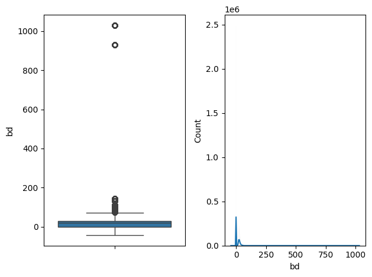

```python
check_outlier(df_cleaned, 'bd')
```

```python
# Replace value that smaller than 0 and bigger than 100 by 0
df_cleaned.bd = np.where(df_cleaned.bd <= 0, 0, df_cleaned.bd)
df_cleaned.bd = np.where(df_cleaned.bd > 100, 0, df_cleaned.bd)
```

```python
# Replace 0 by mean
mean = df_cleaned[df_cleaned.bd.notnull()].bd.mean()
df_cleaned.bd.replace(to_replace=0, value=mean, inplace=True)
df_cleaned.bd = df_cleaned.bd.astype('int')
```

```python
# Replace outlier by average
iqr = df_cleaned.bd.quantile(0.75) - df_cleaned.bd.quantile(0.25)
min = df_cleaned.bd.quantile(0.25) - (1.5*iqr)
max = df_cleaned.bd.quantile(0.75) + (1.5*iqr)
df_cleaned.bd = np.where(df_cleaned.bd > max, mean, df_cleaned.bd)
```

```python
# Filter only the data in range (>2.5% and <97%)
indexs = df_cleaned[(df_cleaned.bd < df_cleaned.bd.quantile(0.025)) | (df_cleaned.bd > df_cleaned.bd.quantile(0.97))].index
df_cleaned.drop(index=indexs, inplace=True)
```

```python
# apply log transform
df_cleaned['bd'] = np.log(df_cleaned['bd']+1)
```

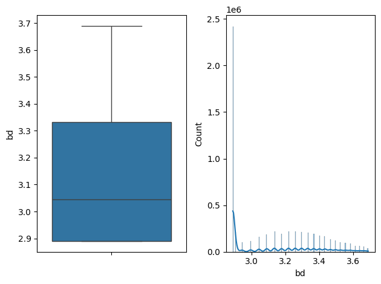

```python
check_outlier(df_cleaned, 'bd')
```

Checking outlier of column **song_length**

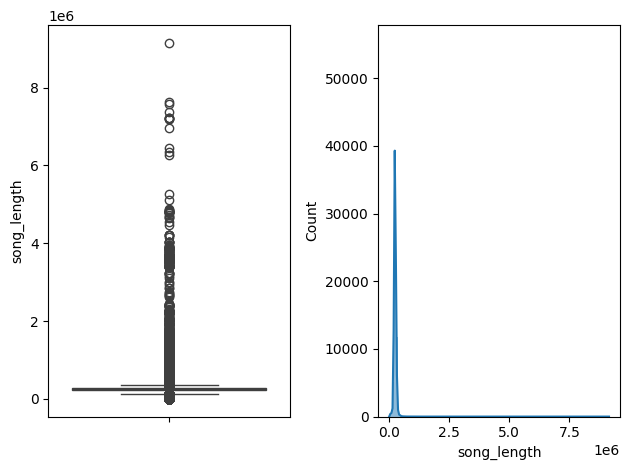

```python
check_outlier(df_cleaned, 'song_length')
```

```python
# Replace outlier by average
mean = df_cleaned[df_cleaned.song_length.notnull()].song_length.mean()
iqr = df_cleaned.song_length.quantile(0.75) - df_cleaned.song_length.quantile(0.25)
min = df_cleaned.song_length.quantile(0.25) - (1.5*iqr)
max = df_cleaned.song_length.quantile(0.75) + (1.5*iqr)
df_cleaned.song_length = np.where(df_cleaned.song_length > max, mean, df_cleaned.song_length)
```

```python
# Filter only the data in range (>2.5% and <97%)
indexs = df_cleaned[(df_cleaned.song_length < df_cleaned.song_length.quantile(0.025)) | (df_cleaned.song_length > df_cleaned.song_length.quantile(0.97))].index
df_cleaned.drop(index=indexs, inplace=True)
```

```python
# apply log transform
df_cleaned['song_length'] = np.log(df_cleaned['song_length']+1)
```

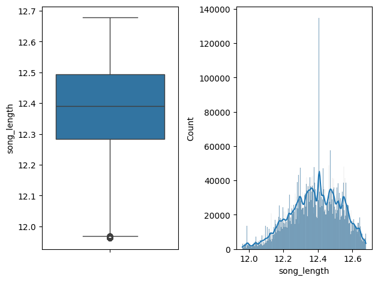

```python
check_outlier(df_cleaned, 'song_length')
```

## Feature Transformation

Transform **registration_init_time** and **expiration_date**

```python
# convert expiration_date and registration_init_time to datetime type
df_cleaned['expiration_date'] = pd.to_datetime(df_cleaned['expiration_date'], format='%Y%m%d')
df_cleaned['registration_init_time'] = pd.to_datetime(df_cleaned['registration_init_time'], format='%Y%m%d')

# create new feature called membership_days
df_cleaned['membership_days'] = (df_cleaned['expiration_date'] - df_cleaned['registration_init_time']).dt.days.astype(int)

# drop all data which membership_days are smaller then 0
indexs = df_cleaned[df_cleaned.membership_days < 0].index
df_cleaned.drop(index=indexs, inplace=True)
```

```python
# drop registration_init_time and expiration_date column
df_cleaned.drop(['registration_init_time', 'expiration_date'], axis=1, inplace=True)
```

Transform **language**

```python
# convert all language category label that smaller then 0 to bigger then 0
df_cleaned.language = np.where(df_cleaned.language < 0, -df_cleaned.language, df_cleaned.language)
```

Create new feature called **freq_song_playback**

```python
song_ids = df_cleaned[df_cleaned.target == 1][['song_id']]
song_ids['freq_song_playback'] = 1
song_id_with_freq_song_playback = song_ids.groupby('song_id').freq_song_playback.sum().reset_index()
df_cleaned = pd.merge(df_cleaned, song_id_with_freq_song_playback, on="song_id", how="left")
df_cleaned.freq_song_playback.fillna(0, inplace=True)
```

Create new feature called **freq_listening_repeatitively**

```python
msnos = df_cleaned[df_cleaned.target == 1][['msno']]
msnos['freq_listening_repeatitively'] = 1
msnos_with_freq_listening_repeatitively = msnos.groupby('msno').freq_listening_repeatitively.sum().reset_index()
df_cleaned = pd.merge(df_cleaned, msnos_with_freq_listening_repeatitively, on="msno", how="left")
df_cleaned.freq_listening_repeatitively.fillna(0, inplace=True)
```

reate new feature called **contain_two_others**

```python
df_cleaned['contain_two_others'] = np.where(
    ((df_cleaned.source_system_tab == 'other') & (df_cleaned.source_screen_name == 'other')) |
    ((df_cleaned.source_system_tab == 'other') & (df_cleaned.source_type == 'other')) |
    ((df_cleaned.source_type == 'other') & (df_cleaned.source_screen_name == 'other')) |
    ((df_cleaned.source_system_tab == 'other') & (df_cleaned.genre_ids == 'other')) |
    ((df_cleaned.source_type == 'other') & (df_cleaned.genre_ids == 'other')) |
    ((df_cleaned.source_screen_name == 'other') & (df_cleaned.genre_ids == 'other')),
    1,
    0
)
```

Drop column **artist_name** and **name**

```python
df_cleaned.drop(["artist_name", "name"], inplace=True, axis=1)
```

Applying Label Encoding

```python
from sklearn.preprocessing import LabelEncoder
encoder = LabelEncoder()
object_type_columns = [column for column in df_cleaned.select_dtypes(object).columns if (column != 'msno') and (column != 'song_id') and (column != 'isrc')]
for column in object_type_columns:
    df_cleaned[column] = encoder.fit_transform(df_cleaned[column])
```

```python
# convert number columns to float
int_type_columns = [column for column in df_cleaned.select_dtypes(int).columns]
for column in int_type_columns:
    df_cleaned[column] = df_cleaned[column].astype('float')
```

```python
df_cleaned
```

|  | msno | song_id | source_system_tab | source_screen_name | source_type | target | city | bd | gender | registered_via | song_length | genre_ids | language | isrc | membership_days | freq_song_playback | freq_listening_repeatitively | contain_two_others |
| --- | --- | --- | --- | --- | --- | --- | --- | --- | --- | --- | --- | --- | --- | --- | --- | --- | --- | --- |
| 0 | FGtllVqz18RPiwJj/edr2gV78zirAiY/9SmYvia+kCg= | BBzumQNXUHKdEBOB7mAJuzok+IJA1c2Ryg/yzTF6tik= | 2.0 | 4.0 | 2.0 | 1.0 | 1.0 | 2.890372 | 1.0 | 7.0 | 12.237920 | 3.0 | 52.0 | GBUM71602854 | 2103.0 | 100.0 | 2411.0 | 1.0 |
| 1 | Xumu+NIjS6QYVxDS4/t3SawvJ7viT9hPKXmf0RtLNx8= | bhp/MpSNoqoxOIB+/l8WPqu6jldth4DIpCm3ayXnJqM= | 1.0 | 1.0 | 1.0 | 1.0 | 13.0 | 3.218876 | 0.0 | 9.0 | 12.558787 | 3.0 | 52.0 | US3C69910183 | 2301.0 | 1.0 | 414.0 | 0.0 |
| 2 | Xumu+NIjS6QYVxDS4/t3SawvJ7viT9hPKXmf0RtLNx8= | JNWfrrC7zNN7BdMpsISKa4Mw+xVJYNnxXh3/Epw7QgY= | 1.0 | 1.0 | 1.0 | 1.0 | 13.0 | 3.218876 | 0.0 | 9.0 | 12.325619 | 3.0 | 52.0 | USUM70618761 | 2301.0 | 2.0 | 414.0 | 0.0 |
| 3 | Xumu+NIjS6QYVxDS4/t3SawvJ7viT9hPKXmf0RtLNx8= | 2A87tzfnJTSWqD7gIZHisolhe4DMdzkbd6LzO1KHjNs= | 1.0 | 1.0 | 1.0 | 1.0 | 13.0 | 3.218876 | 0.0 | 9.0 | 12.451029 | 3.0 | 1.0 | GBUQH1000063 | 2301.0 | 1.0 | 414.0 | 0.0 |
| 4 | FGtllVqz18RPiwJj/edr2gV78zirAiY/9SmYvia+kCg= | 3qm6XTZ6MOCU11x8FIVbAGH5l5uMkT3/ZalWG1oo2Gc= | 2.0 | 4.0 | 2.0 | 1.0 | 1.0 | 2.890372 | 1.0 | 7.0 | 12.143149 | 3.0 | 52.0 | QM3E21606003 | 2103.0 | 142.0 | 2411.0 | 1.0 |
| ... | ... | ... | ... | ... | ... | ... | ... | ... | ... | ... | ... | ... | ... | ... | ... | ... | ... | ... |
| 5764836 | 6xdFzPlrasIDD95mQWXVC3Bg4ptnGYtBl4ztVEZMddU= | VJTxizih/o28kXCbtPbIyWXScoXGvxyYtl6R+0YB5JM= | 1.0 | 1.0 | 1.0 | 1.0 | 4.0 | 3.295837 | 0.0 | 9.0 | 12.498589 | 3.0 | 52.0 | USIR19905031 | 4669.0 | 31.0 | 233.0 | 0.0 |
| 5764837 | ZxbVmt3Kh/XOH+h58c2Kdj6SjFZk+wnUO006IgWzMQE= | z1mqaU9YOX7T/PFDvUoWozdFq7rC3KwaQP7nFVprjMI= | 2.0 | 4.0 | 3.0 | 0.0 | 1.0 | 2.890372 | 1.0 | 7.0 | 12.334488 | 1.0 | 52.0 | USRC11501369 | 1562.0 | 637.0 | 345.0 | 1.0 |
| 5764838 | ZxbVmt3Kh/XOH+h58c2Kdj6SjFZk+wnUO006IgWzMQE= | 750RprmFfLV0bymtDH88g24pLZGVi5VpBAI300P6UOA= | 4.0 | 4.0 | 3.0 | 1.0 | 1.0 | 2.890372 | 1.0 | 7.0 | 12.461873 | 1.0 | 3.0 | TWA451512031 | 1562.0 | 7085.0 | 345.0 | 1.0 |
| 5764839 | 0aH4Hd3ziPSRHClRX8rkeOEaAG5EPPkW1mKGCdXEok0= | G8wgqObgeAMER/rVCIlgcNeQ8mm0CzF/GsxiMK8TTnA= | 0.0 | 4.0 | 2.0 | 1.0 | 5.0 | 2.890372 | 1.0 | 9.0 | 12.407280 | 3.0 | 52.0 | USNO10750721 | 948.0 | 6.0 | 362.0 | 1.0 |
| 5764840 | 0aH4Hd3ziPSRHClRX8rkeOEaAG5EPPkW1mKGCdXEok0= | Ju0VGkjWeBUZCd7r5Az2hUImhMoWxWLUicOedsmvG0g= | 0.0 | 4.0 | 2.0 | 1.0 | 5.0 | 2.890372 | 1.0 | 9.0 | 12.445196 | 3.0 | 52.0 | FR14F9900090 | 948.0 | 4.0 | 362.0 | 1.0 |

5764841 rows × 18 columns

```python
from scipy.stats import chi2_contingency
chi_square_value = {}

# Perform chi-square test for each feature
for feature in ['source_system_tab', 'source_screen_name', 'source_type', 'city', 'gender', 'registered_via', 'genre_ids', 'language', 'contain_two_others']:
    contingency_table = pd.crosstab(df_cleaned[feature], df_cleaned['target'])
    chi2_stat, p_val, _, _ = chi2_contingency(contingency_table)
    chi_square_value[feature] = chi2_stat
chi_square_value = dict(sorted(chi_square_value.items(), key=lambda item: item[1], reverse=True))
print("Feature of important between each categoircal feature and target")
chi_square_value
```

```
Feature of important between each categoircal feature and target
```

```
{'source_type': 1163045.3103413861,
 'source_system_tab': 844684.1075319778,
 'source_screen_name': 696073.1061452602,
 'contain_two_others': 132605.40268660194,
 'language': 24561.66550810251,
 'genre_ids': 15590.839658908026,
 'registered_via': 5636.043658130395,
 'city': 4230.848582705401,
 'gender': 47.75713635081573}
```

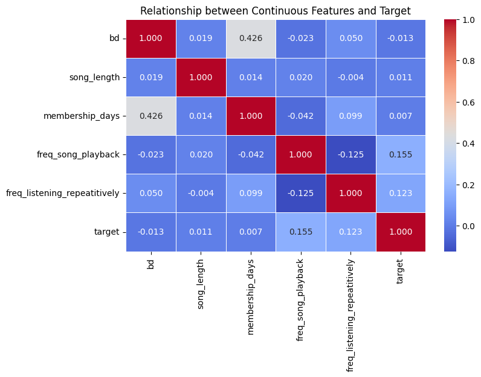

```python
corr = df_cleaned[['bd', 'song_length', 'membership_days', 'freq_song_playback', 'freq_listening_repeatitively', 'target']].corr()
plt.figure(figsize=(8, 5))
sns.heatmap(corr, annot=True, cmap='coolwarm', fmt='.3f', linewidths=.5)
plt.title('Relationship between Continuous Features and Target')
plt.show()
```

# Data Modeling

## Apply Logistic Regression

```python
df = df_cleaned.copy()
df = df.drop(["registered_via", "city", "gender", "membership_days"], axis=1)
```

```python
from sklearn.preprocessing import LabelEncoder
encoder = LabelEncoder()
object_type_columns = [column for column in df.select_dtypes(object).columns]
for column in object_type_columns:
    df[column] = encoder.fit_transform(df[column])
```

```python
from sklearn.model_selection import train_test_split
X = df.drop('target', axis=1)
y = df['target']
X_train, X_test, y_train, y_test = train_test_split(X, y, test_size=0.25, random_state=42, stratify=y)
```

```python
from sklearn.linear_model import LogisticRegression
from sklearn.preprocessing import StandardScaler
from sklearn.pipeline import Pipeline
from sklearn.metrics import accuracy_score

pipeline = Pipeline([
    ('scaler', StandardScaler()),
    ('classifier', LogisticRegression())
])
pipeline.fit(X_train, y_train)
y_pred = pipeline.predict(X_test)
accuracy = accuracy_score(y_test, y_pred)
print("Accuracy score:", accuracy)
```

```
Accuracy score: 0.7011325891906182
```

```python
from sklearn.model_selection import cross_val_score
cross_val_scores = cross_val_score(pipeline, X, y, cv=5, scoring='accuracy')
print("Cross-validation scores:", cross_val_scores)
print("Mean accuracy:", cross_val_scores.mean())
```

```
Cross-validation scores: [0.74239724 0.7334063  0.70729803 0.67342372 0.64216787]
Mean accuracy: 0.6997386323996438
```

```python
from sklearn.metrics import classification_report
report = classification_report(y_test, y_pred)
print("Classification Report:")
print(report)
```

```
Classification Report:
              precision    recall  f1-score   support

         0.0       0.70      0.69      0.69    705195
         1.0       0.70      0.71      0.71    736016

    accuracy                           0.70   1441211
   macro avg       0.70      0.70      0.70   1441211
weighted avg       0.70      0.70      0.70   1441211
```

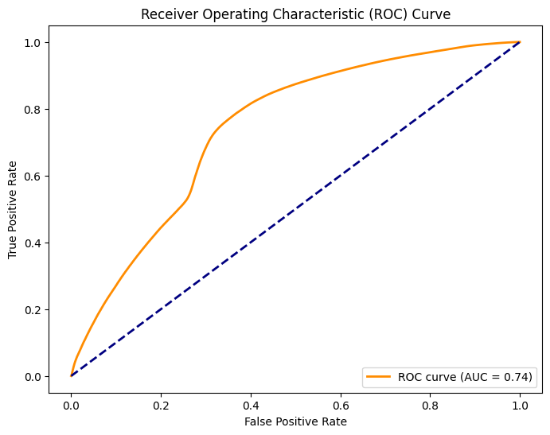

```
Optimal Threshold: 0.43316589520549037
Accuracy with Optimal Threshold: 0.7108889676806519
Confusion Matrix:
[[446867 258328]
 [158342 577674]]
```

```python
from sklearn.metrics import accuracy_score, confusion_matrix, roc_curve, auc
proba_pred = pipeline.predict_proba(X_test)
y_pred = [value[1] for value in proba_pred]
fpr, tpr, thresholds = roc_curve(y_test, y_pred)
roc_auc = auc(fpr, tpr)
# Plot the ROC curve
plt.figure(figsize=(8, 6))
plt.plot(fpr, tpr, color='darkorange', lw=2, label='ROC curve (AUC = {:.2f})'.format(roc_auc))
plt.plot([0, 1], [0, 1], color='navy', lw=2, linestyle='--')
plt.xlabel('False Positive Rate')
plt.ylabel('True Positive Rate')
plt.title('Receiver Operating Characteristic (ROC) Curve')
plt.legend(loc='lower right')
plt.show()
# Get am optimal thresdhold
optimal_threshold_index = np.argmax(tpr - fpr)
optimal_threshold = thresholds[optimal_threshold_index]
print('Optimal Threshold:', optimal_threshold)
# Apply the optimal threshold to make predictions
y_pred_optimal_threshold = (y_pred >= optimal_threshold).astype(int)
# Calculate and print accuracy with the optimal threshold
accuracy_optimal_threshold = accuracy_score(y_test, y_pred_optimal_threshold)
print('Accuracy with Optimal Threshold:', accuracy_optimal_threshold)
# Display confusion matrix
conf_matrix = confusion_matrix(y_test, y_pred_optimal_threshold)
print('Confusion Matrix:')
print(conf_matrix)
```

```python
df.to_csv("kkbox_cleaned_dataset.csv")
```

```python
df
```

|  | msno | song_id | source_system_tab | source_screen_name | source_type | target | bd | song_length | genre_ids | language | isrc | freq_song_playback | freq_listening_repeatitively | contain_two_others |
| --- | --- | --- | --- | --- | --- | --- | --- | --- | --- | --- | --- | --- | --- | --- |
| 0 | 7719 | 52187 | 2.0 | 4.0 | 2.0 | 1.0 | 2.890372 | 12.237920 | 3.0 | 52.0 | 50208 | 100.0 | 2411.0 | 1.0 |
| 1 | 16363 | 155609 | 1.0 | 1.0 | 1.0 | 1.0 | 3.218876 | 12.558787 | 3.0 | 52.0 | 156539 | 1.0 | 414.0 | 0.0 |
| 2 | 16363 | 84269 | 1.0 | 1.0 | 1.0 | 1.0 | 3.218876 | 12.325619 | 3.0 | 52.0 | 202075 | 2.0 | 414.0 | 0.0 |
| 3 | 16363 | 16644 | 1.0 | 1.0 | 1.0 | 1.0 | 3.218876 | 12.451029 | 3.0 | 1.0 | 50496 | 1.0 | 414.0 | 0.0 |
| 4 | 7719 | 23335 | 2.0 | 4.0 | 2.0 | 1.0 | 2.890372 | 12.143149 | 3.0 | 52.0 | 104378 | 142.0 | 2411.0 | 1.0 |
| ... | ... | ... | ... | ... | ... | ... | ... | ... | ... | ... | ... | ... | ... | ... |
| 5764836 | 3992 | 130696 | 1.0 | 1.0 | 1.0 | 1.0 | 3.295837 | 12.498589 | 3.0 | 52.0 | 179197 | 31.0 | 233.0 | 0.0 |
| 5764837 | 17312 | 247000 | 2.0 | 4.0 | 3.0 | 0.0 | 2.890372 | 12.334488 | 1.0 | 52.0 | 188969 | 637.0 | 345.0 | 1.0 |
| 5764838 | 17312 | 36030 | 4.0 | 4.0 | 3.0 | 1.0 | 2.890372 | 12.461873 | 1.0 | 3.0 | 123481 | 7085.0 | 345.0 | 1.0 |
| 5764839 | 1151 | 71554 | 0.0 | 4.0 | 2.0 | 1.0 | 2.890372 | 12.407280 | 3.0 | 52.0 | 184723 | 6.0 | 362.0 | 1.0 |
| 5764840 | 1151 | 86254 | 0.0 | 4.0 | 2.0 | 1.0 | 2.890372 | 12.445196 | 3.0 | 52.0 | 20016 | 4.0 | 362.0 | 1.0 |

5764841 rows × 14 columns